# BUDT758X_Project_Final_Team29

**How many songs were in each year?**

```python
sc1=pd.read_csv("songdata.csv")
```

```python
sc1['Year'].value_counts()
```

```
2018    3
1957    3
1980    3
1976    3
1999    3
1990    3
1967    3
1989    3
1949    3
2013    3
2016    3
1953    2
1988    2
1986    2
1979    2
```

[output cut: 47 more lines]

**How is the chord usage varying across the song structure over the decades?**

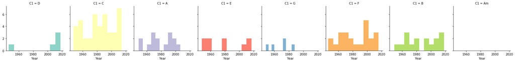

```python
g = sns.FacetGrid(sc1, col='C1', sharex=True,hue='C1',palette='Set3')
g.map(plt.hist, 'Year');
```

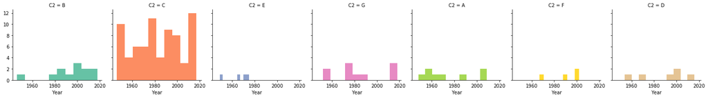

```python
g = sns.FacetGrid(sc1, col='C2', sharex=True, hue='C2', palette='Set2')
g.map(plt.hist, 'Year');
```

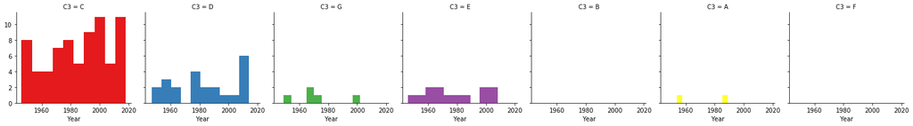

```python
g = sns.FacetGrid(sc1, col='C3', sharex=True,hue='C3', palette='Set1')
g.map(plt.hist, 'Year');
```

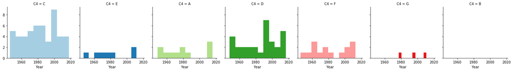

```python
g = sns.FacetGrid(sc1, col='C4', sharex=True,hue='C4', palette='Paired')
g.map(plt.hist, 'Year');
```

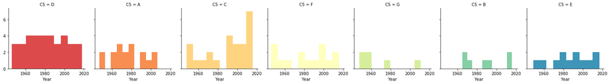

```python
g = sns.FacetGrid(sc1, col='C5', sharex=True,hue='C5', palette='Spectral')
g.map(plt.hist, 'Year');
```

**When Each Chord Peaks**

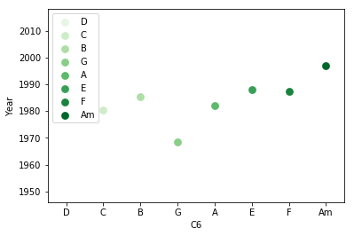

```python
sns.pointplot(x='C6', y='Year', hue='C6', ci=None, palette='Greens', data=sc1).legend(loc='upper left', frameon=True)
plt.ylim([1946,2018]);
```

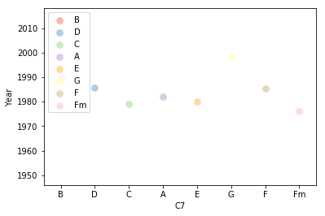

```python
sns.pointplot(x='C7', y='Year', hue='C7', ci=None, palette='Pastel1', data=sc1).legend(loc='upper left', frameon=True)
plt.ylim([1946,2018]);
```

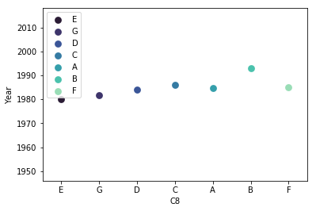

```python
sns.pointplot(x='C8', y='Year', hue='C8', ci=None, palette='mako', data=sc1).legend(loc='upper left', frameon=True)
plt.ylim([1946,2018]);
```

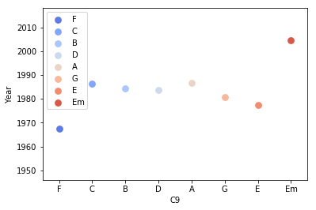

```python
sns.pointplot(x='C9', y='Year', hue='C9', ci=None, palette='coolwarm', data=sc1).legend(loc='upper left', frameon=True)
plt.ylim([1946,2018]);
```

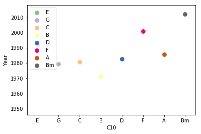

```python
sns.pointplot(x='C10', y='Year', hue='C10', ci=None, palette='Accent', data=sc1).legend(loc='upper left', frameon=True)
plt.ylim([1946,2018]);
```

You can see here that each chord peaks at different times.

**K-Means: Finding Sentiment Analysis**

Chords Common to Clusters of Songs

What we want to do here is find our what chords that each song category/theme (sad, happy, intense) all have in common. We will use a k-means analysis to find this out.

```python
sc1 = pd.read_csv('songdata.csv')
```

```python
letters = ("ABCDEFG")
A=[]
B=[]
C=[]
D=[]
E=[]
F=[]
G=[]
```

```python
for rows in (sc1["Chords"].values):
    if "A" in rows:
        A.append(1)
    else:
        A.append(0)
    if "B" in rows:
        B.append(1)
    else:
        B.append(0)
    if "C" in rows:
        C.append(1)
    else:
        C.append(0)
    if "D" in rows:
        D.append(1)
    else:
        D.append(0)
    if "E" in rows:
        E.append(1)
    else:
        E.append(0)
    if "F" in rows:
        F.append(1)
    else:
        F.append(0)
    if "G" in rows:
        G.append(1)
    else:
        G.append(0)
```

```python
dz = pd.concat([pd.DataFrame(A), pd.DataFrame(B), pd.DataFrame(C), pd.DataFrame(D), pd.DataFrame(E), pd.DataFrame(F), pd.DataFrame(G)], axis=1 )
```

```python
dz.columns=["A", 'B', "c", "d", "e", "f", "g"]
dz.head(2)
```

|  | A | B | c | d | e | f | g |
| --- | --- | --- | --- | --- | --- | --- | --- |
| 0 | 0 | 1 | 1 | 1 | 1 | 1 | 0 |
| 1 | 1 | 0 | 1 | 1 | 1 | 0 | 1 |

```python
a = KMeans(n_clusters=3).fit(dz)
```

```python
preds=a.predict(dz)
preds
```

```
array([0, 1, 1, 1, 1, 2, 1, 0, 1, 1, 2, 1, 0, 1, 1, 1, 2, 1, 1, 2, 1, 1,
       2, 2, 0, 2, 2, 2, 2, 1, 1, 1, 0, 0, 1, 0, 1, 2, 2, 0, 2, 1, 1, 0,
       2, 0, 0, 0, 1, 1, 1, 1, 1, 0, 1, 1, 2, 2, 0, 1, 0, 1, 2, 1, 1, 1,
       1, 0, 2, 2, 1, 1, 1, 2, 2, 1, 1, 1, 1, 2, 1, 2, 2, 1, 1, 2, 2, 1,
       1, 1, 2, 2, 1, 1, 2, 0, 1, 0, 2, 2, 0, 2, 2, 2, 1, 2, 0, 1, 0, 1,
       0, 2, 1, 1, 1, 1, 2], dtype=int32)
```

```python
pre=[1, 0, 2, 1, 0, 0, 1, 2, 2, 1, 0, 1, 2, 2, 0, 0, 0, 0, 0, 2, 0, 0,
       1, 1, 2, 0, 0, 2, 2, 0, 2, 1, 0, 0, 1, 2, 1, 0, 0, 0, 0, 1, 0, 1,
       1, 1, 0, 1, 0, 2, 0, 0, 0, 2, 1, 1, 0, 1, 2, 0, 0, 0, 2, 0, 2, 2,
       1, 1, 0, 0, 1, 2, 2, 2, 0, 2, 2, 2, 0, 0, 0, 1, 1, 2, 0, 0, 0, 2,
       2, 1, 0, 0, 1, 2, 2, 0, 1, 1, 1, 1, 0, 0, 0, 2, 0, 1, 2, 1, 0, 1,
       0, 2, 2, 2, 2, 1]
```

Group 0: Happy songs

Group 1: Sad songs

Group 2: Intense songs

```python
b = zip(sc1["Song"], pre)
c=(dict(b) )
c
```

```
{'Prisoner of Love': 1,
 'Near You': 0,
 'Riders in the Sky': 2,
 'Too Young': 1,
 'Blue Tango': 0,
 'All Shook Up': 0,
 'Nel Blu Dipinto di Blu (Volare)': 1,
 "Tossin' and Turnin'": 1,
 'Wooly Bully': 2,
 'To Sir with Love': 1,
 'Hey Jude': 0,
 'Sugar': 1,
 "Tie a Yellow Ribbon 'Round the Ole Oak Tree": 2,
 'Silly Love Songs': 2,
 "Tonight's the Night (Gonna Be Alright)": 0,
 'My Sharona': 0,
 'Call Me': 0,
 'Physical': 0,
 'Faith': 0,
 'Look Away': 2,
 'Hold On': 0,
 'The Sign': 0,
 'Too Close': 0,
 'Believe': 1,
 'Breathe': 2,
 'In da Club': 0,
 'Bad Day': 0,
 'Low': 2,
 'Tik Tok': 2,
 'Thrift Shop': 2,
 'Happy': 0,
 'Uptown Funk': 1,
 'Love Yourself': 0,
 'Shape of You': 0,
 "God's Plan": 0,
 'Hey! Ba-Ba-Re-Bop': 2,
 'Long Gone': 1,
 'The Hucklebuck': 0,
 'Lawdy Miss Clawdy': 0,
 '(Mama) He Treats Your Daughter Mean': 0,
```

[output cut: 55 more lines]

```
 'Chattahoochee': 0,
 'I Swear': 0,
 'My Maria': 2,
 "It's Your Love": 0,
 'Amazed': 1,
 "Ain't Nothing 'Bout You": 2,
 'The Good Stuff': 1,
 "If You're Going Through Hell (Before the Devil Even Knows)": 0,
 'Watching You': 1,
 "Just Got Started Lovin' You": 0,
 'I Run to You': 2,
 'Crazy Girl': 2,
 'Time Is Love': 2,
 'Cruise': 2,
 'H.O.L.Y.': 1}
```

```python
dz.columns
```

```
Index(['A', 'B', 'c', 'd', 'e', 'f', 'g'], dtype='object')
```

```python
dz.columns = ['A','B','C','D','E','F','G']
```

```python
dz.columns
```

```
Index(['A', 'B', 'C', 'D', 'E', 'F', 'G'], dtype='object')
```

**Adding song type/theme to dataset**

Here, we drop a useless column and rename the column to 'Mood'. Then, we swap out the numeric values of mood for the word of the mood to be more readable.

```python
sc2=pd.concat([sc1,pd.DataFrame(pre)], axis=1)
sc2.drop('Unnamed: 16',inplace=True,axis=1)
sc2.columns = ['Artist','Song','Chords','Single chords','C1','C2','C3','C4','C5','C6','C7','C8','C9','C10','Year','Genre','Mood']
mapping_dict = {0.0: 'Happy',1.0: 'Sad',2.0:'Intense'}
sc2.replace({"Mood": mapping_dict},inplace=True)
sc2.head(10)
```

|  | Artist | Song | Chords | Single chords | C1 | C2 | C3 | C4 | C5 | C6 | C7 | C8 | C9 | C10 | Year | Genre | Mood |
| --- | --- | --- | --- | --- | --- | --- | --- | --- | --- | --- | --- | --- | --- | --- | --- | --- | --- |
| 0 | Perry Como | Prisoner of Love | D-B-C-C-D-D-B-E-F-E | F | D | B | C | C | D | D | B | E | F | E | 1946 | Pop | Sad |
| 1 | Francis Craig | Near You | C-C-D-E-A-C-D-G-C-G | A | C | C | D | E | A | C | D | G | C | G | 1947 | Pop | Happy |
| 2 | Vaughn Monroe Orchestra | Riders in the Sky | A-E-G-A-A-B-C-G-B-C | E | A | E | G | A | A | B | C | G | B | C | 1949 | Pop | Intense |
| 3 | Nat King Cole | Too Young | C-C-C-D-C-G-C-D-C-G | NaN | C | C | C | D | C | G | C | D | C | G | 1951 | Pop | Sad |
| 4 | Leroy Anderson | Blue Tango | A-G-C-C-F-A-D-D-C-C | F | A | G | C | C | F | A | D | D | C | C | 1952 | Pop | Happy |
| 5 | Elvis Presley | All Shook Up | E-A-C-C-D-E-A-C-D-E | NaN | E | A | C | C | D | E | A | C | D | E | 1957 | Pop | Happy |
| 6 | Domenico Modugno | Nel Blu Dipinto di Blu (Volare) | G-C-C-D-G-A-E-C-D-G | A | G | C | C | D | G | A | E | C | D | G | 1958 | Pop | Sad |
| 7 | Bobby Lewis | Tossin' and Turnin' | F-C-E-F-A-C-C-E-F-C | A | F | C | E | F | A | C | C | E | F | C | 1961 | Pop | Intense |
| 8 | Sam the Sham & the Pharaohs | Wooly Bully | B-C-C-D-B-C-D-G-C-B | G | B | C | C | D | B | C | D | G | C | B | 1965 | Pop | Intense |
| 9 | Lulu | To Sir with Love | C-C-D-E-C-D-G-C-D-B | B | C | C | D | E | C | D | G | C | D | B | 1967 | Pop | Sad |

"happy" songs (group 0) tend to cycle DGAC

"Sad" songs (group 1) cycle FBCD -OR- CEF

"Intense" songs (group 2) cycle CCFCD

Happy songs tend to start slow and gradually go uphill in each stanza. Sad songs tend to start high and gradually go downhill in each stanza. Intense songs tend to fluctuate wildly between up and down in each stanza.

In an alternative embodiment, sad songs start to go uphill and then go downhill, instead, so one's brain starts to expect a happy stanza, and so when it turns out sad, it seems extra sad.

**Adding decade to our dataframe**

```python
sc2['Decade']=(sc2['Year'] // 10) * 10
sc2.head()
```

|  | Artist | Song | Chords | Single chords | C1 | C2 | C3 | C4 | C5 | C6 | C7 | C8 | C9 | C10 | Year | Genre | Mood | Decade |
| --- | --- | --- | --- | --- | --- | --- | --- | --- | --- | --- | --- | --- | --- | --- | --- | --- | --- | --- |
| 0 | Perry Como | Prisoner of Love | D-B-C-C-D-D-B-E-F-E | F | D | B | C | C | D | D | B | E | F | E | 1946 | Pop | Sad | 1940 |
| 1 | Francis Craig | Near You | C-C-D-E-A-C-D-G-C-G | A | C | C | D | E | A | C | D | G | C | G | 1947 | Pop | Happy | 1940 |
| 2 | Vaughn Monroe Orchestra | Riders in the Sky | A-E-G-A-A-B-C-G-B-C | E | A | E | G | A | A | B | C | G | B | C | 1949 | Pop | Intense | 1940 |
| 3 | Nat King Cole | Too Young | C-C-C-D-C-G-C-D-C-G | NaN | C | C | C | D | C | G | C | D | C | G | 1951 | Pop | Sad | 1950 |
| 4 | Leroy Anderson | Blue Tango | A-G-C-C-F-A-D-D-C-C | F | A | G | C | C | F | A | D | D | C | C | 1952 | Pop | Happy | 1950 |

**Which mood is the most popular?**

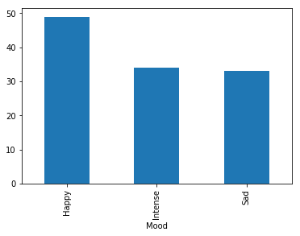

```python
sc2.groupby('Mood')['Mood'].count().plot(kind='bar')
```

Happy is the most popular with intense and sad fairly close together.

```python
sentiment_mapping_dict = {'Happy':0.0,'Sad':1.0,'Intense':2.0}
# Remap the values of the dataframe
sc2['Sentiment']= sc2['Mood'].map(sentiment_mapping_dict)
sc2.head()
#sns.barplot(x='Genre', y='Sentiment', hue='Genre', data=sc2, palette='icefire', ci=None, estimator=np.mean).legend(frameon=True, title='Sentiment');
```

|  | Artist | Song | Chords | Single chords | C1 | C2 | C3 | C4 | C5 | C6 | C7 | C8 | C9 | C10 | Year | Genre | Mood | Decade | Sentiment |
| --- | --- | --- | --- | --- | --- | --- | --- | --- | --- | --- | --- | --- | --- | --- | --- | --- | --- | --- | --- |
| 0 | Perry Como | Prisoner of Love | D-B-C-C-D-D-B-E-F-E | F | D | B | C | C | D | D | B | E | F | E | 1946 | Pop | Sad | 1940 | 1.0 |
| 1 | Francis Craig | Near You | C-C-D-E-A-C-D-G-C-G | A | C | C | D | E | A | C | D | G | C | G | 1947 | Pop | Happy | 1940 | 0.0 |
| 2 | Vaughn Monroe Orchestra | Riders in the Sky | A-E-G-A-A-B-C-G-B-C | E | A | E | G | A | A | B | C | G | B | C | 1949 | Pop | Intense | 1940 | 2.0 |
| 3 | Nat King Cole | Too Young | C-C-C-D-C-G-C-D-C-G | NaN | C | C | C | D | C | G | C | D | C | G | 1951 | Pop | Sad | 1950 | 1.0 |
| 4 | Leroy Anderson | Blue Tango | A-G-C-C-F-A-D-D-C-C | F | A | G | C | C | F | A | D | D | C | C | 1952 | Pop | Happy | 1950 | 0.0 |

Do different genres have different sentiments?

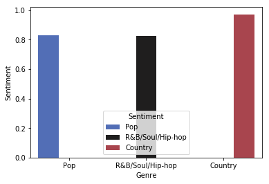

```python
sns.barplot(x='Genre', y='Sentiment', hue='Genre', data=sc2, palette='icefire', ci=None, estimator=np.mean).legend(frameon=True, title='Sentiment');
```

This shows us that country has a higher sentiment than r&b, which in turn has about the same sentiment as pop.

**How do sentiments change over time and by genre?**

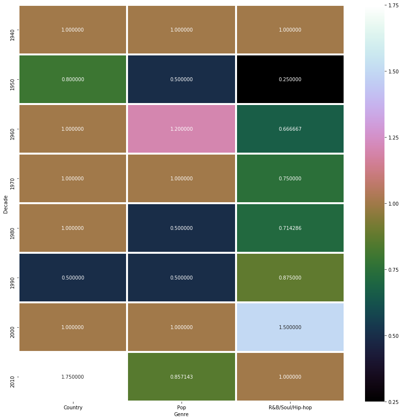

```python
table = sc2.groupby(['Decade','Genre'])['Sentiment'].mean().unstack()
plt.figure(figsize=(15,15))
sns.heatmap(table, cmap='cubehelix', annot=True, fmt='f', square=False, linewidths=3);
```

Sentiments tend to remain around 1, while there are some periods where they deviate.

Pop and r&b both started out sad in the 1940s and then turned happier in the following decade where they're at their peak in terms of happiness. R&b tends to be sadder whereas pop tends to be happier as seen for the 80s and 90s. Also, country music seems to be on a continuous sad sound, except the 1990s where it seems a little more joyful.

**How does chord popularity vary over decades?**

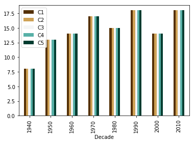

```python
sc2.groupby('Decade')['C1','C2','C3','C4','C5'].count().plot(kind='bar', cmap='BrBG')
```

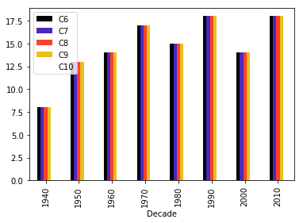

```python
sc2.groupby('Decade')['C6','C7','C8','C9','C10'].count().plot(kind='bar',cmap='CMRmap')
```

This shows us that the chords do not really move relative to another in each decade. There are decades where, in aggregate, more music is produced, but there does not seem to be an affect of time on chords relative use to other chords.

**What are the most popular chord transitions?**

```python
df3 = pd.read_csv('songdata.csv')
```

```python
looper = df3["Chords"].copy()
letters =["A","B","C","D","E","F","G"]
zeroni = [0,0,0,0,0,0,0]
grid = pd.DataFrame({'A': zeroni, 'B': zeroni, 'C': zeroni, 'D': zeroni, 'E': zeroni, 'F': zeroni, 'G': zeroni}, index=letters)
grid
```

|  | A | B | C | D | E | F | G |
| --- | --- | --- | --- | --- | --- | --- | --- |
| A | 0 | 0 | 0 | 0 | 0 | 0 | 0 |
| B | 0 | 0 | 0 | 0 | 0 | 0 | 0 |
| C | 0 | 0 | 0 | 0 | 0 | 0 | 0 |
| D | 0 | 0 | 0 | 0 | 0 | 0 | 0 |
| E | 0 | 0 | 0 | 0 | 0 | 0 | 0 |
| F | 0 | 0 | 0 | 0 | 0 | 0 | 0 |
| G | 0 | 0 | 0 | 0 | 0 | 0 | 0 |

```python
#chord tranitions, for each line in df[chords], and for each transition, increment the relevant transition in the grid by 1
for lines in looper:
    oldLetters = "X" #initialize, no transition in first chord of song
    for nextLetter in lines:
        if nextLetter in letters: #if not a dash char
            if oldLetters in letters: #if not starting the song
                grid.loc[nextLetter, oldLetters] = grid.loc[nextLetter, oldLetters] + 1
            oldLetters = nextLetter

grid
```

|  | A | B | C | D | E | F | G |
| --- | --- | --- | --- | --- | --- | --- | --- |
| A | 10 | 13 | 10 | 29 | 17 | 14 | 7 |
| B | 11 | 4 | 11 | 23 | 8 | 3 | 3 |
| C | 57 | 29 | 145 | 39 | 34 | 47 | 50 |
| D | 5 | 4 | 166 | 9 | 8 | 1 | 5 |
| E | 17 | 16 | 40 | 26 | 16 | 10 | 6 |
| F | 2 | 4 | 7 | 15 | 29 | 10 | 5 |
| G | 10 | 3 | 18 | 40 | 8 | 6 | 3 |

What this shows us is the chord transitions. For example,A transitions to C 57 times in our dataset. C is transitioned to very often, which is not surprising considering (i've explained why C is important several times above --- see above). This information is important because it could help a musician write songs and figure out what kind of chord transitions they should utilize.

**Conclusion**

In conclusion, we used google to search the internet for music chords that we scraped. We then had to perform several data processing and analysis tasks. Our analysis led us to several conclusions. First, C is the most popular chord in total but also the chord that most commonly begins a song. This is not surprising because C is the most popular chord to play music in since it contains no sharp or flat notes. Another interesting thing we found is that chords vary in popularity over time, but the C chord has been fairly consistent in being popular at most times.

We found that songs that share a theme also share similar chords. Our K-means analysis shows us what songs can be described in three categories: happy, sad and intense. Happy songs tend to start off low and get higher while sad songs tend to do the opposite: they start high and get low. Intense songs are a blend. They tend fluctuate wildly between low and high, which is what adds intensity to the songs.

So why is our analysis meaningful?

We have found that the chords that makeup each of these song categories. This would be very useful to a musician or record label because they can make songs that elicit a certain emotion from the crowd. If a musician wants to open up their set with a happy song and end with an intense song, they can use our analysis to do just that. If they want to make their audience moody with a sad song, they can do just that. Music makes people feel a certain way and our analysis breaks down how that is done. Our analysis can show musicians, record labels, and interested people how to garner a specific emotion through chord use.

Our analysis is meaningful because it shows not only what makes a good song, but what makes a song happy, sad or intense. Let's say you're a musician who wants to make an album that has emotional variety. That musician could use our analysis of the song themes to make an album that contains happy, sad and intense songs. He or she could also mimic the chords from the most popular songs in hope that his or her music would be as popular. Our analysis could be used to musicians and record labels alike to produce music that is diverse and statistically similar to the most popular songs.

Finally, our analysis is impactful because it demystifies music. Since music has such an emotional component, it is often viewed as some ethereal thing, but our analysis shows that music can be systematically broken down and classified. Perhaps this analysis could inspire someone to do the same and lead to other conclusions.